# Econometria Aplicada à Finanças Aula 11

# Diagnósticos Gráficos da Normalidade dos Resíduos

## Gráfico Quantil-Quantil Normal

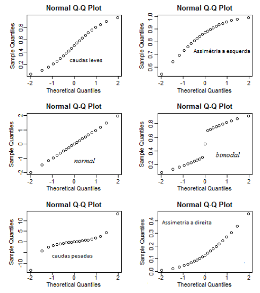

## Gráfico Quantil-Quantil Normal

```r
# estima um modelo de regressão linear simples
ps_lm <- lm(Expenditure ~ Income, data = PublicSchools)

# gráfico quantil-quantil normal dos resíduos
plot(ps_lm, which = 2)
```

## Gráfico Quantil-Quantil Normal

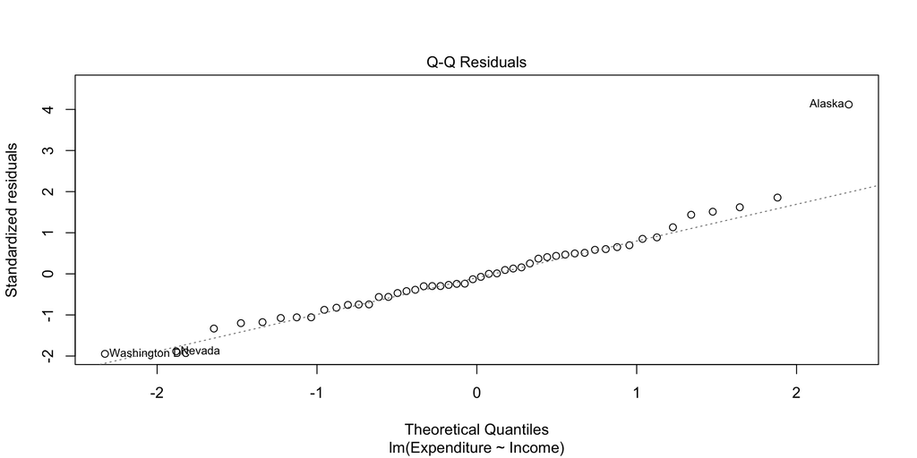

## Gráficos Q-Q Normal - Pacote ggpubr

```r
# extrai os resíduos do objeto ps_lm
ps_lm_residuos <- residuals(ps_lm)

# pacote utilizado
library(ggpubr)

# Gráfico quantil-quantil dos resíduos
ggqqplot(ps_lm_residuos) +
  xlab("Quantis teóricos de uma distribuição normal padrão") +
  ylab("Resíduos")
```

## Gráficos Q-Q Normal - Pacote ggpubr

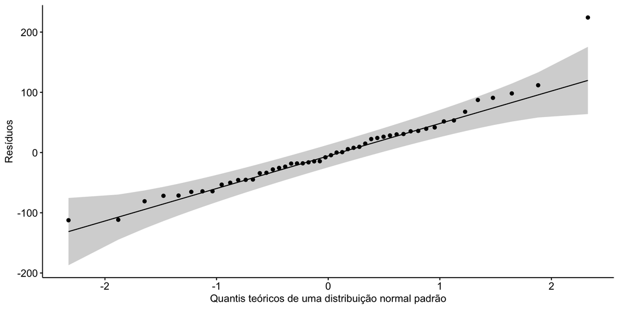

# Testes da Hipótese da Normalidade dos Resíduos

## Testando a Hipótese de Normalidade

**Teste de Jarque-Bera**

- Uma distribuição normal é simétrica e tem um coeficiente de curtose de 3.
- A curtose de uma distribuição normal é 3, então o excesso de curtose ($b_{2} - 3$) é zero.
- O coeficiente de assimetria (skewness) e o de curtose são, respectivamente, o terceiro e o quarto momentos (padronizados) de uma distribuição.
- Jarque e Bera (1980) criaram um teste da normalidade dos resíduos, verificando se o coeficiente de assimetria e o coeficiente de curtose são conjuntamente iguais a 0 e 3, respectivamente.
- Pode-se provar que os coeficientes de assimetria e curtose podem ser expressos, respectivamente, como:

$$b_1 = \frac{E[u^3]}{\left( {\sigma ^2} \right)^{3 / 2}}{\quad}\hbox{e}{\quad}b_2 =
\frac{E[u^4]}{\left( {\sigma ^2} \right)^2}$$

- A estatística do teste de Jarque-Bera é dada por:

$$W = T\left[ {\frac{b_1 ^2}{6} + \frac{(b_2 - 3)^2}{24}} \right] \sim \chi_{(2)}^2$$

- Estimamos $b_{1}$ e $b_{2}$ utilizando os resíduos da regressão de MQO.
- **Hipótese Nula**: A amostra segue uma distribuição normal.

$$H_0: b_1 = 0 \quad \text{e} \quad b_2 = 3$$

- **Hipótese alternativa**: A amostra não segue uma distribuição normal.

$$H_1: b_1 \neq 0 \quad \text{ou} \quad b_2 \neq 3$$

## Teste de Jarque-Bera

**Característica**

- Este é um teste **assintótico**.
- Isto é, ele possui boas propriedades (poder) para amostras “grandes”.

## Teste de Jarque-Bera em R

```r
# carrega o pacote
library(DescTools)

# função para calcular o teste de Jarque-Bera
JarqueBeraTest(
  x, # vetor numérico com os resíduos
  robust = TRUE, # TRUE padrão, versão robusta do teste
  method = c("chisq", "mc"), # método para caluclar valores criticos
  N = 0, # número de simulações de Monte Carlo
  na.rm = FALSE # remover NA?
)
```

## Teste de Jarque-Bera em R

```r
# carrega o pacote
library(DescTools)

# teste de Jarque-Bera - versào robusta
JarqueBeraTest(ps_lm_residuos)
```

```
    Robust Jarque Bera Test

data:  ps_lm_residuos
X-squared = 20.8, df = 2, p-value = 0.00003
```

## Comparação de Testes de Normalidade

**Yap e Sim (2011)**

- Segundo os resultados do artigo de Yap e Sim (2011), o teste de Shapiro-Wilk obteve desempenho igual ou superior, em termos do poder do teste, aos demais testes comparados no estudo, sendo que o teste de Jarque-Bera estava incluído.
- O algoritmo utilizado para a implementação do teste de Shapiro-Wilk na linguagem R (utilizada neste artigo submetido) é o proposto por Royston (1995), o qual pode ser utilizado para qualquer n entre $3 \leq n \leq 5000$.

## Teste de Shapiro-Wilk

**Descrição**

- Teste de normalidade baseado na correlação entre os dados ordenados e os quantis esperados de uma normal.
- A estatística do teste é:

$$W = \frac{\left( \sum_{i=1}^{n} a_i X_{(i)} \right)^2}{\sum_{i=1}^{n} (X_i - \bar{X})^2}$$

Onde:

- $X_{(i)}$: $i$-ésimo menor valor da amostra (ordenação crescente)
- $\bar{X}$: média amostral
- $a_i$: coeficientes baseados nos quantis da normal teórica

#### Interpretação da Estatística

- **Numerador**: mede o **alinhamento linear** dos dados ordenados com os quantis da normal.
- **Denominador**: mede a **variabilidade total** dos dados.
- Se os dados seguem a normal: os termos se alinham bem $\Rightarrow W \approx 1$
- Se houver desvio da normalidade: o alinhamento é fraco $\Rightarrow W \ll 1$

#### Cálculo dos Coeficientes $a_i$

- Baseados nos **quantis esperados da normal padrão**, ordenados como vetor $m = (m_1, \dots, m_n)$.
- São computados para maximizar o poder do teste.
- Derivados via:

$$a = \frac{m^\top V^{-1}}{\left( m^\top V^{-1} V^{-1} m \right)^{1/2}}$$

Onde:

- $V$: matriz de covariância dos quantis normais esperados
- O vetor $a$ é simétrico e seus valores são pré-calculados em R

## Teste de Shapiro-Wilk em R

```r
# teste de Shapiro-Wilk de normalidade dos resíduos
shapiro.test(ps_lm_residuos)
```

```
    Shapiro-Wilk normality test

data:  ps_lm_residuos
W = 0.948, p-value = 0.029
```

## Outros Testes

**Teste de Anderson-Darling**

- É um teste de normalidade baseado na função de distribuição empírica.
- Verifica se os dados seguem uma **distribuição normal** comparando a distribuição observada com a teórica.
- É um teste **“omnibus”**, ou seja, busca detectar **qualquer tipo de desvio da normalidade** (assimetria, curtose).
- **Dá mais peso às caudas** da distribuição, sendo mais sensível a valores extremos do que outros testes.
- Medida da distância entre as distribuições:

$$A^2 = n \int_{-\infty}^{\infty} \frac{[F_n(x) - F(x)]^2}{F(x)(1 - F(x))} , dF(x)$$

- Função: `nortest::ad.test()`

## Outros Testes

**Teste de Cramer-von Mises**

- É também um teste **“omnibus”**, ou seja, busca detectar **qualquer tipo de desvio da normalidade** (assimetria, curtose), como o teste de Anderson-Darling.
- Também compara a função de distribuição empírica dos dados com a função de distribuiçõa teórica da distribuição normal.
- Menos sensível a outliers do que o teste de Anderson-Darling, por não enfatizar as caudas.
- Medida da distância entre as distribuições:

$$W^2 = n \int_{-\infty}^{\infty} \left[ F_n(x) - F(x) \right]^2 , dF(x)$$

- Função: `nortest::cvm.test()`

## Outros Testes

**Teste de Lilliefors**

- Versão modificada do teste de Kolmogorov-Smirnov, que não exige que os parâmetros da distribuição sejam especificados previamente.
- É um teste omnibus, sensível a qualquer tipo de desvio da normalidade, mas com maior foco no corpo da distribuição do que nas caudas.
- Menos poderoso que o teste de Shapiro-Wilk, especialmente em amostras pequenas, mas útil por sua simplicidade e aplicabilidade quando parâmetros são estimados.
- Função: `nortest::lillie.test()`

## Outros Testes

**Teste de D’Agostino-Pearson**

- Similar ao Jarque-Bera, verifica a normalidade dos dados baseando-se na curtose e assimetria simultaneamente.
- Função: `moments::agostino.test()`

## Não Normalidade dos Resíduos

**O que Fazemos se Encontrarmos evidências de Não-normalidade?**

- Não é óbvio o que devemos fazer!
- Podemos usar um método que não assume normalidade:
  - regressão **robusta**
  - regressão **não-paramétrica**
- Mas são métodos difíceis, quais são suas propriedades?
- Em muitas situações, um ou dois resíduos extremamente fora do padrão é que nos levam a rejeitar a suposição de normalidade.

# Diagnósticos de Observações Influentes

## Observações Influentes

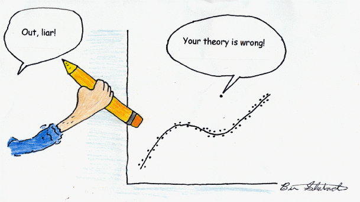

Fora, mentiroso! Sua teoria está errada!

## Diangósticos de Exclusão

**Motivação**

- Observações influentes podem distorcer significativamente os resultados de um modelo de regressão linear.
- Algumas medidas ajudam a identificá-las de forma sistemática.

## Diangósticos de Exclusão

**Estratégia de Belsley, Kuh e Welsch (1980)**

Exclua a observação $i$ e calcule:

- as estimativas $\hat{\beta}_{(i)}$ e $\hat{\sigma}_{(i)}$,
- e as previsões associadas $\hat{y}_{(i)} = X \hat{\beta}_{(i)}$.
- a ideia é identificar observações (linhas) cuja remoção causa uma grande mudança nestas estimativas.
- Observações influentes podem ou não ter grande **alavancagem** e podem ou não ser **outliers**, mas tendem a possuir pelo menos uma dessas características.

## Observações Influentes

**Conceito**

São Observações que afetam fortemente os resultados de Modelos de Regressão Linear.

Um dado ou observação influente pode ser:

- um **Ponto de Alavancagem** (*Leverage Point*);
- um **Outlier**;
- ou Ambos.

## Outlier

**Conceito**

- **Outliers**: são observações influentes que “puxam” a reta de regressão (ou superfície) em uma direção ou outra.
- São valores da variável **resposta** $y$ relativamente distantes dos outros valore de $Y$.

## Pontos de Alavancagem

**Conceito**

- Pontos de alta alavancagem são observações discrepantes ou distantes da maioria dos valores das variáveis **explicativas** $X$.
- Pontos de Alavancagem podem ser, ou não, outliers.
- O termo *alavancagem* refere-se à distância do valor de uma observação da variável explicativa $X$ do valor médio desta variável.
- As alavancas podem denotar pontos muito próximos ou muito distantes da(s) média(s).

## Pontos de Alavancagem e Outliers

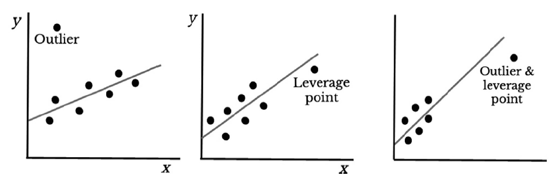

## Matriz $H$ (*Hat matrix*)

**Descrição**

Considere o seguinte modelo de regressão linear:

$$Y = X \cdot \beta + \epsilon$$

na qual:

- $Y$ é um vetor $(n \times 1)$ de observações da variável resposta;
- $X$ é uma matriz $(n \times p)$ de variáveis explicativas ($p$);
- $\epsilon$ é o vetor $(n \times 1)$ de erros; e
- $\beta$ é o vetor $(p \times 1)$ dos parâmetros a serem estimados.

A estimativa $\hat{\beta}$ do vetor $\beta$ é dada por:

$$\hat{\beta} = (X^{T} X)^{-1} X^{T} Y$$

## Matriz $H$ (*Hat matrix*)

**Descrição**

Podemos calcular os valores estimados $\hat{Y}$ de $Y$ se conhecermos $\hat{\beta}$:

$$\hat{Y} = X \hat{\beta} = X (X^{T} X)^{-1} X^{T} Y$$

A matriz hat $H$ é então definida como:

$$H = X (X^{T} X)^{-1} X^{T}$$

Em particular, o elemento diagonal $h_{ii}$ é definido por:

$$h_{ii} = x_i (X^{T} X)^{-1} x^{t}_i$$

sendo $x_i$ a i-ésima linha de $X$.

## Matriz $H$ (*Hat matrix*)

**Propriedades**

- Matriz Simétrica: $H = H^T$
- Matriz Idempotente: $H = H^2 = H \times H$
- $0 \leq h_{ii} \leq 1$

**Interpretações**

- O elemento $(i, j)$ dessa matriz mede a influência da $j$-ésima observação no $i$-ésimo valor previsto.
- Os elementos diagonais ($h_{ii}$) podem ser interpratados como o efeito das observações ($y_i$) nas previsões (ou estimativas) correspondentes da variável resposta $\hat{y}_i$.

$$h_{ii} = \frac{\partial \hat{y}_i}{\partial y_i}$$

## Matriz $H$

**Exemplo**

Considere os dados a seguir onde $Y$ é uma variável resposta relacionada à variável explicativa $X$:

| $X$ | $Y$ |
| --- | --- |
| 50 | 6 |
| 52 | 8 |
| 55 | 9 |
| 75 | 7 |
| 57 | 8 |
| 58 | 10 |

O modelo de regressão linear simples é escrito na seguinte forma matricial:

$$Y = X \cdot \beta + \epsilon$$

## Matriz $H$

**Exemplo**

$$Y = X \cdot \beta + \epsilon$$

sendo:

$$Y = \begin{pmatrix}
6 \\ 8 \\ 9 \\ 7 \\ 8 \\ 10
\end{pmatrix}, \quad
X = \begin{pmatrix}
1 & 50 \\
1 & 52 \\
1 & 55 \\
1 & 75 \\
1 & 57 \\
1 & 58
\end{pmatrix}$$

$\epsilon$ é o vetor $(6 \times 1)$ de resíduos, e $\beta$ é o vetor $(2 \times 1)$ dos parâmetros.

## Matriz $H$

**Exemplo**

A matriz $H$ é calculada por:

$$H = X (X' X)^{-1} X' =
\begin{pmatrix}
0.32 & 0.28 & 0.22 & -0.17 & 0.18 & 0.16 \\
0.28 & 0.25 & 0.21 & -0.08 & 0.18 & 0.16 \\
0.22 & 0.21 & 0.19 & 0.04 & 0.17 & 0.17. \\
-0.17 & -0.08 & 0.04 & 0.90 & 0.13 & 0.17 \\
0.18 & 0.18 & 0.17 & 0.13 & 0.17 & 0.17 \\
0.16 & 0.16 & 0.17 & 0.17 & 0.17 & 0.17
\end{pmatrix}$$

O traço de $H$ é igual ao número de parâmetros no modelo:

$$tr(H) = 0.32 + 0.25 + 0.19 + 0.90 + 0.17 + 0.17 = 2$$

## Matriz Hat em R

```r
# cria o vetor Y
Y <- c(6, 8, 9, 7, 8, 10)
Y
```

```
[1]  6  8  9  7  8 10
```

```r
# Cria a matriz X
X <- matrix(c(1, 50,
              1, 52,
              1, 55,
              1, 75,
              1, 57,
              1, 58), ncol = 2, byrow = TRUE)
X
```

```
     [,1] [,2]
[1,]    1   50
[2,]    1   52
[3,]    1   55
[4,]    1   75
[5,]    1   57
[6,]    1   58
```

## Matriz Hat em R

```r
# cria uma data frame
df <- data.frame(Y = Y, X1 = X[, 1], X2 = X[, 2])

# gráfico de dispersão entre Y e X
plot(Y ~ X[,2], pch = 19, col = "black", data = df)

# estima modelo de regressao simples
reg_yx <- lm(Y ~ X[,2], data = df)

# adiciona reta estimada ao grafico
abline(reg_yx)
```

## Matriz Hat em R

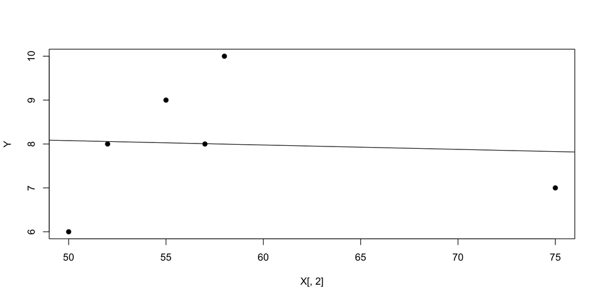

## Matriz Hat em R

```r
# Calculo da matriz Hat = H = X (X' X)^{-1} X'
X_transposta <- t(X)
X_inversa <- solve(X_transposta %*% X)
matriz_hat <- X %*% X_inversa %*% X_transposta
round(matriz_hat, 2)
```

```
      [,1]  [,2] [,3]  [,4] [,5] [,6]
[1,]  0.32  0.28 0.22 -0.17 0.18 0.16
[2,]  0.28  0.25 0.21 -0.08 0.18 0.16
[3,]  0.22  0.21 0.19  0.04 0.17 0.17
[4,] -0.17 -0.08 0.04  0.91 0.13 0.17
[5,]  0.18  0.18 0.17  0.13 0.17 0.17
[6,]  0.16  0.16 0.17  0.17 0.17 0.17
```

```r
# elementos hii
hii <- diag(matriz_hat)
round(hii, 2)
```

```
[1] 0.32 0.25 0.19 0.91 0.17 0.17
```

## Matriz Hat em R

**Exemplo**

- Um valor crítico proposto para $h_{ii}$ é:

$$h_{ii} = x_i (X^{T} X)^{-1} x^{t}_i > 2 \times\frac{p}{n}$$

- Neste caso, há dois parâmetros ($p = 2$) e seis observações ($n = 6$). ou seja, o valor crítico é igual a $\frac{4}{6} = 0,67$.
- Comparando os componentes de $h_ii$ com este valor, vemo que, com exceção da observação $i = 4$, todas as observações têm $h_{ii} < 0,67$.
- Assim, comprovamos que a quarta observação (linha) é um **ponto de alavancagem** para estes dados.

```r
# quarta obsevervação é um ponto de alavancagem
hii > 0.67
```

```
[1] FALSE FALSE FALSE  TRUE FALSE FALSE
```

## Matriz Hat em R

```r
# remove a quarta observação (linha)
Y_sempa <- Y[-4]
X_sempa <- X[-4, ]

# cria uma nova data frame sem a quarta observação
df_sempa <- data.frame(Y = Y_sempa, X1 = X_sempa[, 1], X2 = X_sempa[, 2])

# cria um novo gráfico de dispersão sem a quarta observação
plot(Y_sempa ~ X_sempa[,2], pch = 19, col = "black", data = df_sempa)

# estima o novo modelo de regressão sem a quarta observação
reg_yx_sempa <- lm(Y_sempa ~ X_sempa[,2], data = df_sempa)

# adiciona a reta estimada ao novo gráfico
abline(reg_yx_sempa)
```

## Matriz Hat em R

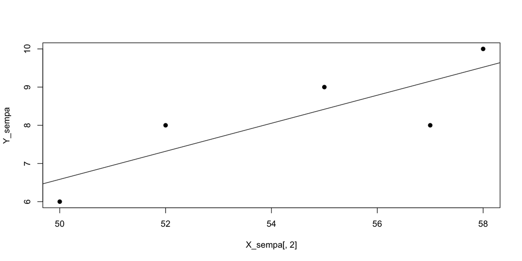

## Matriz Hat em R

```r
# usando a função interna hatvalues
hatvalues(reg_yx)
```

```
      1       2       3       4       5       6
0.32052 0.25198 0.18679 0.90556 0.16841 0.16674
```

## Alavancagem

**Alavancagem Alta**

- Alavancagem alta $h_{ii}$ geralmente significa valores duas ou três vezes maiores que o valor médio $\frac{p}{n}$.
- A alavancagem depende apenas de $X$ e não de $y$.
- **Pontos de Alavancagem “Bons”**: Pontos de alavancagem alta com $y_i$ típico.
- **Pontos de Alavancagem “Ruins”**: Pontos de alavancagem alta com $y_i$ incomum.

## Diangósticos de Exclusão

**Outras medidas**

- **DFFIT**: Mudança nos valores ajustados/previstos (versão escalada: **DFFITS**).
- **DFBETA**: Mudança nas estimativas dos parâmetros/coeficientes (versão escalada: **DFBETAS**).
- **COVRATIO**: Mudança na matriz de variância-covariância.
- **Distância de Cook**: Sumariza o quanto todos os valores previstos no modelo de regressão mudam quando a $i$-ésima observação é removida. Pode ser expressa em função da alavancagem (*leverage*).

## Diangósticos de Exclusão

**Estatísticas básicas**

Funções em R:

- `dfbetas()`
- `dffits()`
- `covratio()`
- `cooks.distance()`

## Diagnósticos de Exclusão

**DFBETAS**

Mede o impacto da exclusão da observação *i* sobre **cada coeficiente** $\beta_j$ da regressão:

$$\mathrm{DFBETAS}_{j(i)} =
\frac{\hat{\beta}_j - \hat{\beta}_{j(i)}}{\hat{\sigma}_{(i)} \cdot \sqrt{\mathrm{Var}(\hat{\beta}_j)}}$$

- Avalia a mudança em unidades de erro padrão.
- Um valor elevado indica que a observação *i* altera substancialmente a estimativa do coeficiente $\beta_j$.

-Regra prática: considerar influente se

$$\left| \mathrm{DFBETAS}_{j(i)} \right| > \frac{2}{\sqrt{N}}.$$

## DFBETAS

```r
dfbetas(reg_yx)
```

```
  (Intercept)      X[, 2]
1 -1.24349477  1.09510683
2 -0.01486494  0.01254092
3  0.13776276 -0.09897470
4  7.33314676 -7.93707581
5 -0.00054225  0.00023016
6  0.08932273  0.01529886
```

## Diagnósticos de Exclusão

**Resíduo Studentizado**

Mede o quanto a observação *i* se desvia do valor ajustado quando ela própria é excluída da estimação:

$$\hat{e}^{\,\text{stu}}_i =
\frac{\hat{e}_{(i)}}{\left[V(\hat{e}_{(i)} \mid x)\right]^{1/2}}
=
\frac{\hat{e}_i}{\hat{\sigma}_{(i)} \sqrt{1 - h_i}}$$

- Altos valores absolutos indicam que a observação *i* possui um erro anormalmente grande.
- Observações com $\left| \hat{e}^{,\text{stu}}_i \right| > 2$ devem ser investigadas.

## Resíduo Studentizado

```r
rstudent(reg_yx)
```

```
        1         2         3         4         5         6
-2.301413 -0.037133  0.629104 -2.837613 -0.005030  1.673390
```

## Diagnósticos de Exclusão

**DFFITS**

Mede o impacto da exclusão da observação *i* sobre o valor ajustado/previsto $\hat{y}_i$:

$$\mathrm{DFFITS}_i =
\frac{\hat{y}_i - \hat{y}_{(i)}}{\hat{\sigma}_{(i)} h_i^{1/2}} =
\left( \frac{h_i}{1 - h_i} \right)^{1/2} \hat{e}^{,\text{stu}}_i$$

Combina informação sobre:

- **Alavancagem ($h_i$)**: quão “extrema” é a observação nos regressores.
- **Resíduo studentizado**: quão mal o ponto é ajustado.

Regras práticas:

$\left| \mathrm{DFFITS}_i \right| > 2 \left( \frac{K}{N} \right)^{1/2}$ (amostras pequenas)

$\left| \mathrm{DFFITS}_i \right| > 3 \left( \frac{K}{N} \right)^{1/2}$ (amostras grandes)

## DFFITS

```r
dffits(reg_yx)
```

```
         1          2          3          4          5          6
-1.5806362 -0.0215524  0.3015120 -8.7867523 -0.0022636  0.7485506
```

## Diagnósticos de Exclusão

**COVRATIO**

- Mede o impacto da observação *i* sobre a precisão conjunta dos coeficientes da regressão.
- Compara o determinante da matriz de covariância dos estimadores $\hat{\boldsymbol{\beta}}$ **com e sem** a observação $i$:

$$\text{COVRATIO}_i =
\frac{|\widehat{\text{Cov}}_{(i)}(\boldsymbol{\beta})|}{|\widehat{\text{Cov}}(\boldsymbol{\beta})|}$$

Regra prática:

$$\left| \text{COVRATIO}_i - 1 \right| > \frac{3K}{N}$$

## COVRATIO

```r
covratio(reg_yx)
```

```
      1       2       3       4       5       6
0.34210 2.37448 1.70625 1.38698 2.13776 0.57075
```

## Diagnósticos de Exclusão

**Distância de Cook**

Mede a **influência conjunta** da observação *i* sobre todos os coeficientes da regressão:

$$D_i = \frac{1}{K \cdot \hat{\sigma}^2}
\sum_{j=1}^N \left( \hat{y}_j - \hat{y}_{j(i)} \right)^2
= \frac{ \hat{e}_i^2 }{K \cdot \hat{\sigma}^2 } \cdot \frac{h_i}{(1 - h_i)^2}$$

Combina:

- **Magnitude do resíduo** da observação *i*
- **Alavancagem** da observação *i*
- **Número de parâmetros** do modelo

Regras práticas:

- Em geral: **$D_i > 1$** indica potencial influência.
- Ou comparar com o percentil de uma distribuição **F(K, N–K)**

## Distância de Cook

```r
cooks.distance(reg_yx)
```

```
            1             2             3             4             5
 0.6022806410  0.0003095283  0.0535427689 13.9715324817  0.0000034158
            6
 0.1932086986
```

## A função `influence.measures()`

**Descrição**

- **Função de conveniência**: Calcula as principais quantidades, como `dfbetas()`, `dffits()`, `covratio()`, `cooks.distance()` e `hatvalues()`.
- **Observações influentes**: Observações que são incomuns em pelo menos uma das medidas de influência são destacadas com `*`.

## A função `influence.measures()`

```r
influence.measures(reg_yx)
```

```
Influence measures of
     lm(formula = Y ~ X[, 2], data = df) :

     dfb.1_ dfb.X..2    dffit cov.r      cook.d   hat inf
1 -1.243495  1.09511 -1.58064 0.342  0.60228064 0.321   *
2 -0.014865  0.01254 -0.02155 2.374  0.00030953 0.252
3  0.137763 -0.09897  0.30151 1.706  0.05354277 0.187
4  7.333147 -7.93708 -8.78675 1.387 13.97153248 0.906   *
5 -0.000542  0.00023 -0.00226 2.138  0.00000342 0.168
6  0.089323  0.01530  0.74855 0.571  0.19320870 0.167
```

## A função `influence.measures()`: PublicSchools

```r
summary(influence.measures(ps_lm))
```

```
Potentially influential observations of
     lm(formula = Expenditure ~ Income, data = PublicSchools) :

              dfb.1_  dfb.Incm dffit   cov.r   cook.d  hat
Alaska        -2.39_*  2.52_*   2.65_*  0.55_*  2.31_*  0.21_*
Mississippi    0.07   -0.07     0.08    1.14_*  0.00    0.08
Washington DC  0.66   -0.71    -0.77_*  1.01    0.28    0.13_*
```

## A função `influence.measures()`

**Interpretação**

- O Alasca se destaca por qualquer medida de influência e é claramente um ponto de alavancagem ruim.
- Washington, DC, parece ser um ponto de alavancagem ruim (mas não tão ruim quanto o Alasca).
- O Mississippi está associado a uma grande mudança nas covariâncias.

## A função `influence.measures()`

Excluindo as observações influentes:

```r
# Cria um gráfico de dispersão entre xpenditure (y) e Income (x)
# Define o intervalo do eixo y entre 230 e 830
plot(Expenditure ~ Income,
     data = ps,
     ylim = c(230, 830))

# Ajusta um modelo de regressão linear simples usando os dados da base 'ps'
ps_lm <- lm(Expenditure ~ Income, data = ps)

# Adiciona a reta de regressão ao gráfico
abline(ps_lm)

# Identifica os pontos que possuem grande influência no modelo de regressão
id <- which(apply(influence.measures(ps_lm)$is.inf, 1, any))

# Adiciona rótulos aos pontos identificados como influentes
text(ps[id, 2:1], rownames(ps)[id], pos = 1, xpd = TRUE)

# Ajusta um novo modelo de regressão linear excluindo os pontos
# identificados como influentes
ps_noinf <- lm(Expenditure ~ Income, data = ps[-id, ])

# Adiciona a nova reta de regressão ao gráfico, com um estilo
# de linha diferente
abline(ps_noinf, lty = 2)

# Cria uma legenda para diferenciar as duas retas de regressão
legend(
  "topleft",
  c("amostra completa", "sem obs. influentes"),
  lty = 1:2,
  bty = "n"
)
```

## A função `influence.measures()`

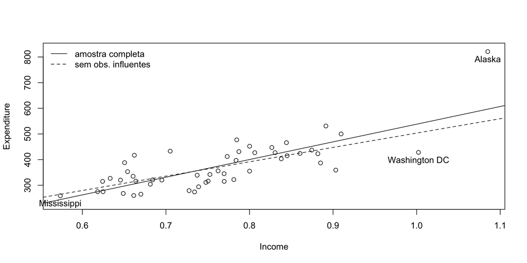

## Diangósticos de Exclusão

**Limitações**

- **Problema**: Outliers do mesmo tipo podem mascarar uns aos outros em diagnósticos de exclusão.

**Solução**:

- Em problemas de baixa dimensão, podemos construir gráficos e obter as medidas de influência.
- Em dados de alta dimensão, podemos usar regressões que suportem alterações em uma certa porcentagem dos dados (**Regressão Robusta**).

# Diagnóstico Gráfico dos Resíduos de Modelos de Regressão Linear em R

## Gráficos de Diagnóstico dos Resíduos

**Resíduos de Modelos de Regressão Linear**

O método `plot()` para objetos do tipo `"lm"` fornece os seguintes gráficos dos resíduos:

- **Resíduos versus valores ajustados**: para verificar $E(\varepsilon|X) = 0$.
- **Gráfico QQ**: resíduos ordenados versus quantis normais para verificar a normalidade.
- **Gráfico escala-localização**: $\sqrt{|\hat{r}_i|}$ (dos resíduos padronizados $r_i$ versus os valores ajustados $\hat{y}_i$, para verificar a suposição de independentes, identicamente distribuídois (i.i.d.), em particular $Var(\varepsilon|X) = \sigma^2I$.
- **Mais 3 Gráficos** envolvendo combinações de resíduos padronizados, alavancagem e distância de Cook.

Por padrão, apenas quatro dos seis gráficos disponíveis são exibidos: `which = c(1:3, 5)`.

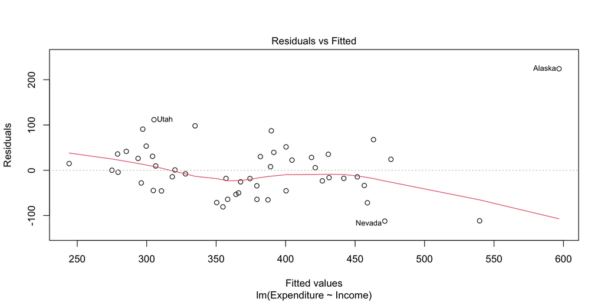

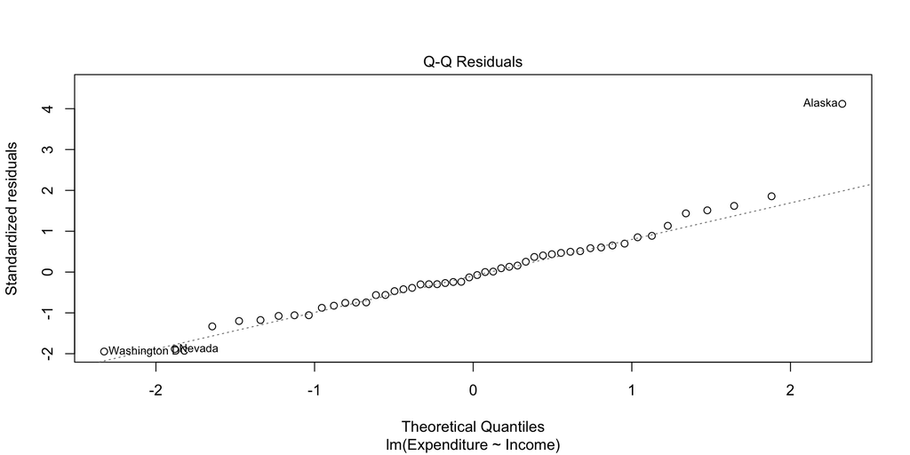

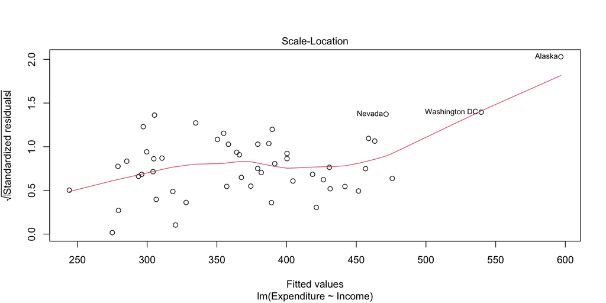

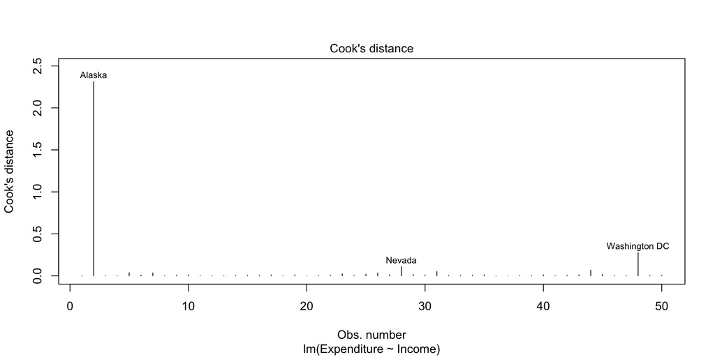

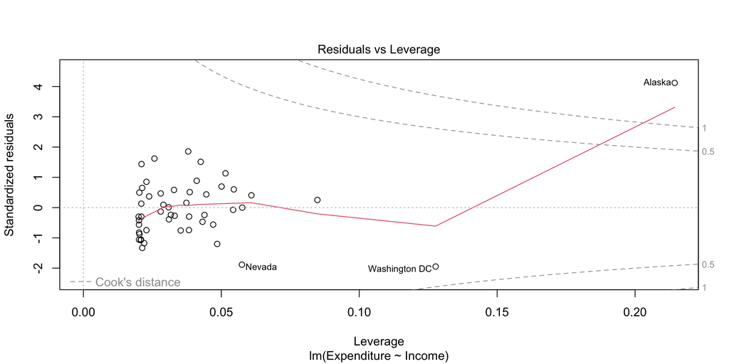

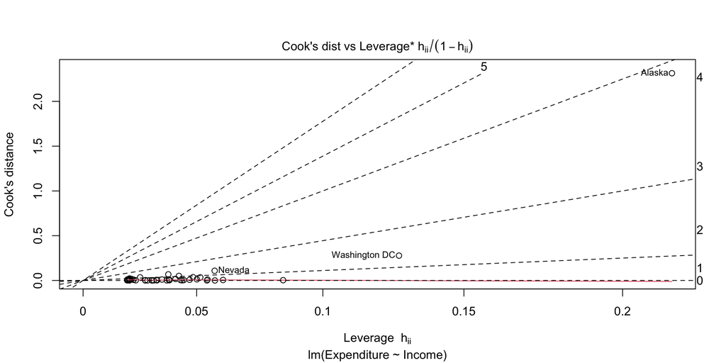

```r
# exibe os gráficos dos resíduos
# gráficos de 1 até 6
plot(ps_lm, which = 1:6)
```

## Diagnósticos de Observações Influentes

**Interpretação**

O estado do Alasca se destaca em todos os gráficos:

- **Resíduo grande** (gráfico `which = 1`).
- Causa assimetria na **cauda superior** da distribuição empírica dos resíduos (gráfico `which = 2`).
- Lança dúvidas sobre a suposição de homocedasticidade (gráfico `which = 3`).
- Corresponde a uma distância de Cook extraordinariamente alta (gráficos `which = 4 e 6`).
- Possui a maior alavancagem (gráficos `which = 5 e 6`).

Outras observações também se destacam, mas nenhuma é tão dominante quanto o Alasca.

## Diagnósticos de Observações Influentes

**Conclusão**

- Não estamos sugerindo que observações incomuns devam ser descartadas.
- Se essas medidas indicarem que uma observação contém erro, tente corrigi-lo.
- Ao examinar observações com alta alavancagem, grande resíduo studentizado, ou valores altos de DFBETAS ou DFFITS, o analista pode aprender quais características dos dados são mais relevantes.
- Todo analista de dados deve examinar cuidadosamente seus dados — e essas ferramentas ajudam a sistematizar essa investigação.

# Regressão Robusta (ou Resistente)

## Regressão Robusta

**Introdução**

- Todos os métodos de estimação dependem de suposições para sua validade.
- Dizemos que um estimador é **robusto** se ele continua fornecendo informação útil mesmo quando algumas dessas suposições não são satisfeitas.
- A **regressão robusta** refere-se a métodos de estimação — geralmente aplicados  
  ao modelo de regressão linear — que são **insensíveis a outliers** e a possíveis  
  **pontos de alta alavancagem**.
- Esses métodos foram desenvolvidos entre meados das décadas de 1960 e 1980.  
  Atualmente, os métodos *L1* (regressão por mínimos valores absolutos) são provavelmente os mais utilizados.

## Conceito Básico

**Ponto de Quebra (*Breakdown Point*) e Robustez**

- portanto, se $x_n$ for suficientemente grande, então $\bar{x}_n$ pode ser tornada tão grande quanto se desejar, independentemente dos outros $n-1$ valores. Assim, o ponto de quebra da média é $1/n$.
- Por outro lado, a mediana amostral pode tolerar até 50% de valores “ruins”.

## Estimador-M

**Descrição - parte 1**

A Estimação-M (ou estimadores-M), introduzida por Huber (1964), é um método geral de estimação que generaliza o método da máxima verossimilhança, daí a letra *M*.

Considere o modelo linear:

$$y_i = \beta_0 + \beta_1 x_{i1} + \cdots + \beta_p x_{ip} + \varepsilon_i = x_i' \beta + \varepsilon_i$$

A ideia central é **atribuir menor peso a observações com resíduos grandes**,  
pois elas contêm menos informação sobre a relação entre $y$ e $x$.

O estimador-M ($\hat{\beta}$) é obtido minimizando uma função objetivo $\rho(e_i)$:

$$\min_{\beta}= \sum_{i=1}^n \rho(e_i) = \sum_{i=1}^n \rho(y_i - x_i' \beta)$$

onde $\rho$ é uma função perda que cresce mais lentamente que $e^2$ (caso dos MQO).

## Estimador-M

**Descrição - parte 2**

- Uma função $\rho$ razoável deve ter as seguintes propriedades, como:
- $\rho(e_i) \geq 0$, sempre não-negativa
- $\rho(0) = 0$
- monótona em $|e_i|$: $\rho(e_i) \geq \rho(e_i^{'})$ para $|e_i| > |e_i^{'}|$.

## Estimador-M

**Descrição - parte 3**

Derivando a função objetivo em relação a $\beta$ e igualando a zero:

$$\sum_{i=1}^n \psi(y_i - x_i' \beta) x_i = 0$$

onde $\psi(e) = \frac{d\rho(e)}{de}$ é chamada de **função de influência**.

Definindo o peso:

$$w_i = \frac{\psi(e_i)}{e_i},$$

temos o sistema de equações:

$$\sum_{i=1}^n w_i (y_i - x_i' \beta) x_i = 0.$$

## Estimador-M

**Descrição - parte 4**

Essa forma corresponde a um problema de **mínimos quadrados ponderados**, mas como os pesos dependem dos resíduos, é necessário um procedimento iterativo: *iteratively reweighted least-squares* (IRLS).

1. Começar com estimativas iniciais $\beta^{(0)}$ de MQO
2. A cada iteração $t$, calcular os resíduos $e_i^{t-1}$ e os pesos associados

$w_i^{t-1} = w[e_i^{t-1}]$ da iteração anterior.

3. Resolva para as novas estimativas de MQ ponderados:

$$b^{(t)} = [X^{'}W^{t-1}X]^{-1} [X^{'}W^{t-1}y]$$

4. Os passos 2 e 3 são repetidos as estimativas dos parâmetros convergirem.

A matriz de variância-covariância assintótica de $\hat{\beta}$ é:

$$\hat{\text{Var}}(\hat{\beta}) = \frac{E(\psi^2)}{[E(\psi^{''})]^2}(X^{'}X)^{-1}$$

## Funções Objetivo

**Resumo**

As funções $\rho(e)$ e pesos $w(e)$ mais usadas são:

| Método | Função Objetivo $\rho(e)$ | Peso $w(e)$ |
| --- | --- | --- |
| **MQO** | $\rho(e) = e^2$ | $w(e) = 1$ |
| **Huber** | $\rho(e) = \begin{cases}\frac{1}{2}e^2, & \|e\| \le k \\ k\|e\| - \frac{1}{2}k^2, & \|e\| > k \end{cases}$ | $w(e) = \begin{cases} 1, & \|e\| \le k \\ k/\|e\|, & \|e\| > k \end{cases}$ |
| **Bisquare** | $\rho(e) = \begin{cases}\frac{k^2}{6}\left[1 - \left(1 - (e/k)^2\right)^3\right], & \|e\| \le k \\ \frac{k^2}{6}, & \|e\| > k \end{cases}$ | $w(e) = \begin{cases} \left[1 - (e/k)^2\right]^2, & \|e\| \le k \\ 0, & \|e\| > k \end{cases}$ |

## Funções Objetivo

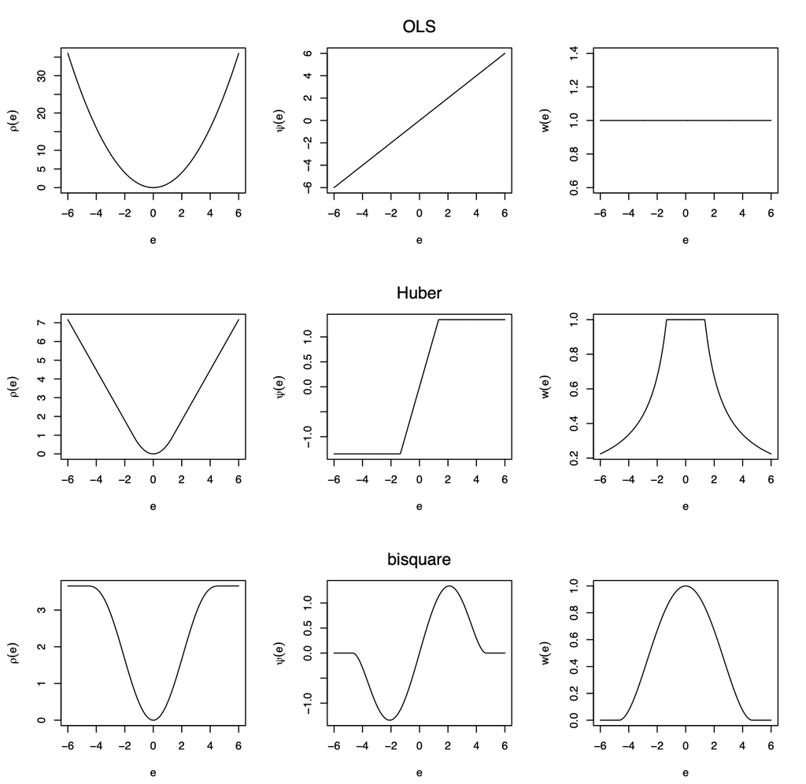

Tanto a função objetivo MQO quanto a de Huber aumentam indefinidamente à medida que o resíduo $e$ se afasta de 0, mas a função dos MQO cresce mais rapidamente. Em contraste, a função objetivo bisquare eventualmente se estabiliza (para $|e| > k$). O método MQO atribui peso igual a todas as observações; os pesos do estimador de Huber diminuem quando $|e| > k$; e os pesos do estimador bisquare diminuem assim que $e$ se afasta de 0, sendo nulos quando $|e| > k$. A função $\psi$ do estimador bisquare retorna a zero para resíduos suficientemente grandes.

## Propriedades das Funções

**Descrição**

- O estimador **Huber** é uma transição entre MQO e L1.
- O **Bisquare** (ou *biweight*) ignora completamente observações com resíduos muito grandes.
- O parâmetro $k$ é uma **constante de ajuste (tuning constant)**:
  - Menores valores → maior robustez, menor eficiência sob normalidade.
  - Valores usuais: $k = 1{,}345\sigma$ (Huber), $k = 4{,}685\sigma$ (Bisquare).

Em aplicações, $\sigma$ é estimado de forma robusta, por exemplo:

$$\hat{\sigma} = \frac{\text{mediana}(|e_i|)}{0{,}6745}.$$

## Regressão de Influência Limitada

**Descrição**

Alguns estimadores-M ainda são sensíveis a **pontos de alta alavancagem**.

Surgem então os **estimadores de influência limitada** (*Bounded-Influence*), com ponto de quebra alto.

#### Exemplo: Mínimos Quadrados Aparados (*Least Trimmed Squares*, LTS)

Ordenam-se os resíduos ao quadrado:  
$|e|_{(1)}^2 \le |e|_{(2)}^2 \le \cdots \le |e|_{(n)}^2$

O estimador LTS minimiza a soma dos $m$ menores:

$$LTS(\beta) = \sum_{i=1}^m |e|_{(i)}^2,$$

com

$$m \approx \left\lfloor \frac{n}{2} \right\rfloor + \left\lfloor \frac{k+2}{2} \right\rfloor$$

## Estimadores Robustos

**Observações**

- A estimação de modelos de regressão robusta (estimadores-M, LTS, MM) é **computacionalmente complexa**.
- **Não há** fórmulas simples para os erros-padrão dos coeficientes.
- O **estimador-MM** combina vantagens:
  - Ponto de quebra alto do LTS.
  - Eficiência do estimador-M sob normalidade.
  - Usa função $\psi$ redescendente (como a do Bisquare).
- Em R, esses estimadores são implementados em funções como `MASS::rlm()` e `robustbase::lmrob()`, entre outras.

## Resumo — Tipos de Estimadores Robustos

**Resumo**

| Tipo | Características principais | Função típica |
| --- | --- | --- |
| **M-estimador (Huber, Bisquare)** | Reduz influência de resíduos grandes | $\psi(e)$ e $w(e)$ |
| **LTS (Least Trimmed Squares)** | Minimiza apenas parte dos menores resíduos | $\sum_{i=1}^m e_{(i)}^2$ |
| **MM-estimador** | Combina alta robustez e eficiência | Inicia com LTS e refina com M |
| **L1/Quantílica** | Minimiza valores absolutos, estima a mediana condicional | $\sum \|e_i\|$ |

**Nota:** Em econometria, esses métodos parecem não ser tão amplamente utilizados quanto merecem (Zaman, Rousseeuw e Orhan, 2001).

## Exemplo: Modelo de Solow

**Ilustração**

O modelo Solow-Swan ou modelo de crescimento exógeno é um modelo econômico de crescimento econômico de longo prazo.

Verbete Wikipedia: [Modelo de Solow-Swan](https://en.wikipedia.org/wiki/Solow–Swan_model)

## Regressão Robusta

**Exemplo**

Modelo clássico de crescimento econômico de Solow.

$$\log\left(\frac{Y_t}{Y_0}\right) = \beta_1 + \beta_2 \log(Y_0) + \beta_3 \log(K_t) + \beta_4 \log(n_t + 0.05) + \varepsilon_t$$

- $Y_t$ e $Y_0$ são o PIB real nos períodos $t$ e $0$.
- $K_t$ é uma medida de acumulação de capital físico.
- $n_t$ é o crescimento populacional (acrescido de 5% para o crescimento da produtividade do trabalho).

## Regressão Robusta

**Dados**

O conjunto de dados `OECDGrowth` fornece essas variáveis para o período de 1960–1985 para todos os países da OCDE com uma população superior a 1 milhão.

- `gdp85` e `gdp60` são o PIB real (por pessoa em idade ativa).
- `invest` é a média anual das proporções de investimento doméstico real em relação ao PIB real.
- `popgrowth` é o crescimento anual da população.

## Visão Geral dos Dados

```r
# carrega os dados OECDGrowth
data("OECDGrowth", package = "AER")

# visão geral da estrutura dos dados
dplyr::glimpse(OECDGrowth)
```

```
Rows: 22
Columns: 6
$ gdp85     <int> 23060, 25014, 17669, 16646, 16876, 19406, 17776, 18546, 1796…
$ gdp60     <int> 12361, 16364, 4648, 7827, 8609, 10515, 8630, 9650, 9819, 316…
$ invest    <dbl> 0.2542, 0.2397, 0.3658, 0.2828, 0.2645, 0.2915, 0.3852, 0.29…
$ school    <dbl> 0.106, 0.119, 0.109, 0.080, 0.093, 0.107, 0.115, 0.089, 0.08…
$ randd     <dbl> 0.0125, 0.0255, 0.0240, 0.0110, 0.0140, 0.0110, 0.0120, 0.02…
$ popgrowth <dbl> 0.0197, 0.0154, 0.0124, 0.0036, 0.0045, 0.0058, 0.0076, 0.00…
```

## Visão Geral dos Dados

```r
# exibe todas as observações
head(OECDGrowth, 22)
```

```
               gdp85 gdp60 invest school  randd popgrowth
Canada         23060 12361 0.2542  0.106 0.0125    0.0197
USA            25014 16364 0.2397  0.119 0.0255    0.0154
Japan          17669  4648 0.3658  0.109 0.0240    0.0124
Austria        16646  7827 0.2828  0.080 0.0110    0.0036
Belgium        16876  8609 0.2645  0.093 0.0140    0.0045
Denmark        19406 10515 0.2915  0.107 0.0110    0.0058
Finland        17776  8630 0.3852  0.115 0.0120    0.0076
France         18546  9650 0.2972  0.089 0.0205    0.0099
Germany        17969  9819 0.3095  0.084 0.0245    0.0050
Greece          9492  3164 0.2885  0.079 0.0020    0.0070
Ireland        12054  5454 0.2877  0.114 0.0080    0.0105
Italy          16055  7086 0.3139  0.071 0.0095    0.0064
Netherlands    16937 10008 0.2789  0.107 0.0205    0.0138
Norway         22107  8977 0.3494  0.100 0.0145    0.0068
Portugal        7925  2965 0.2608  0.058 0.0035    0.0060
Spain          11876  4916 0.2817  0.080 0.0045    0.0090
Sweden         20826 11364 0.2636  0.079 0.0225    0.0031
Switzerland    22428 14532 0.3142  0.048 0.0230    0.0084
Turkey          5150  2884 0.2323  0.055 0.0020    0.0271
United Kingdom 17034 10004 0.2067  0.089 0.0225    0.0033
Australia      20617 12824 0.3128  0.098 0.0105    0.0200
New Zealand    17319 13569 0.2680  0.119 0.0095    0.0170
```

## Estimação do Modelo de Solow com MQO

```r
# estima o modelo de Solow
solow_lm <- lm(log(gdp85/gdp60) ~ log(gdp60) + log(invest) +
                 log(popgrowth + .05), data = OECDGrowth)

# exibe os resultados
summary(solow_lm)
```

## Estimação do Modelo de Solow com MQO

```
Call:
lm(formula = log(gdp85/gdp60) ~ log(gdp60) + log(invest) + log(popgrowth +
    0.05), data = OECDGrowth)

Residuals:
    Min      1Q  Median      3Q     Max
-0.1840 -0.0399 -0.0078  0.0451  0.3188

Coefficients:
                      Estimate Std. Error t value  Pr(>|t|)
(Intercept)             2.9759     1.0216    2.91    0.0093 **
log(gdp60)             -0.3429     0.0565   -6.07 0.0000098 ***
log(invest)             0.6501     0.2020    3.22    0.0048 **
log(popgrowth + 0.05)  -0.5730     0.2904   -1.97    0.0640 .
---
Signif. codes:  0 '***' 0.001 '**' 0.01 '*' 0.05 '.' 0.1 ' ' 1

Residual standard error: 0.133 on 18 degrees of freedom
Multiple R-squared:  0.746, Adjusted R-squared:  0.704
F-statistic: 17.7 on 3 and 18 DF,  p-value: 0.0000134
```

## Estimação do Modelo de Solow com MQO

**Modelo de Solow**

- Ajuste razoável para uma regressão com secção-cruzada.
- Os coeficientes de `gdp60` e `invest` são altamente significativos.
- O coeficiente de `popgrowth` está no limiar de significância ao nível de 10%.

## Análise de Outliers/Alavangencagem

```r
# pacote necessário
library(olsrr)

# gráfico de diagnóstico dos resíduos
ols_plot_resid_lev(solow_lm)
```

## Análise de Outliers/Alavangencagem

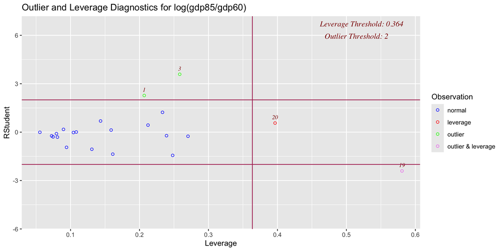

## Análise de Outliers/Alavangencagem

```r
# identificando as observações incomuns
OECDGrowth %>%
slice(1,3,19,20)
```

```
               gdp85 gdp60 invest school  randd popgrowth
Canada         23060 12361 0.2542  0.106 0.0125    0.0197
Japan          17669  4648 0.3658  0.109 0.0240    0.0124
Turkey          5150  2884 0.2323  0.055 0.0020    0.0271
United Kingdom 17034 10004 0.2067  0.089 0.0225    0.0033
```

## Regressão Robusta: função `lmrob()`

**Objetivo**

A função `lmrob()` do pacote **robustbase** estima modelos de regressão linear robusta, reduzindo a influência de **outliers** e de **observações com alta alavancagem**.

## Estimação do Modelo de Solow com Regressão Robusta

```r
# pacote necessário
library(robustbase)

# estima o modelo de Solow com LTS
solow_robusta <- lmrob(log(gdp85/gdp60) ~ log(gdp60) + log(invest) + log(popgrowth + .05),
                 data = OECDGrowth, setting = "KS2014")

# exibe os resultados
summary(solow_robusta)
```

## Estimação do Modelo de Solow com Regressão Robusta

```
Call:
lmrob(formula = log(gdp85/gdp60) ~ log(gdp60) + log(invest) + log(popgrowth +
    0.05), data = OECDGrowth, setting = "KS2014")
 \--> method = "SMDM"
Residuals:
     Min       1Q   Median       3Q      Max
-0.14996 -0.03247 -0.00339  0.03791  0.39006

Coefficients:
                      Estimate Std. Error t value  Pr(>|t|)
(Intercept)             2.1822     0.9175    2.38     0.029 *
log(gdp60)             -0.3226     0.0497   -6.49 0.0000042 ***
log(invest)             0.4977     0.1838    2.71     0.014 *
log(popgrowth + 0.05)  -0.7164     0.2549   -2.81     0.012 *
---
Signif. codes:  0 '***' 0.001 '**' 0.01 '*' 0.05 '.' 0.1 ' ' 1

Robust residual standard error: 0.115
Multiple R-squared:  0.755, Adjusted R-squared:  0.714
Convergence in 13 IRWLS iterations

Robustness weights:
 16 weights are ~= 1. The remaining 6 ones are
     Canada         USA       Japan      Norway      Turkey New Zealand
      0.655       0.992       0.274       0.996       0.974       0.960
Algorithmic parameters:
      tuning.chi1       tuning.chi2       tuning.chi3       tuning.chi4
 -0.5000000000000   1.5000000000000                NA   0.5000000000000
               bb       tuning.psi1       tuning.psi2       tuning.psi3
  0.5000000000000  -0.5000000000000   1.5000000000000   0.9500000000000
      tuning.psi4        refine.tol           rel.tol         scale.tol
               NA   0.0000001000000   0.0000001000000   0.0000000001000
        solve.tol          zero.tol       eps.outlier             eps.x
  0.0000001000000   0.0000000001000   0.0045454545455   0.0000000000176
warn.limit.reject warn.limit.meanrw
  0.5000000000000   0.5000000000000
     nResample         max.it       best.r.s       k.fast.s          k.max
          1000            500             20              2           2000
   maxit.scale      trace.lev            mts     compute.rd      numpoints
           200              0           1000              0             10
fast.s.large.n
          2000
              setting                   psi           subsampling
             "KS2014"                 "lqq"         "nonsingular"
                  cov compute.outlier.stats
            ".vcov.w"                "SMDM"
seed : int(0)
```

## Interpretação do Resultado

**Interpretação**

- Os **pesos de robustez** (*Robustness weights*) são atribuídos a cada observação com base no tamanho do seu **resíduo padronizado**.
- Eles são derivados de uma **função de perda $\rho$** (ou mais especificamente, da derivada dela, a função $\psi$), que determina **quanto peso** uma observação terá na reestimação final dos coeficientes.
- **Observações com resíduos pequenos**: recebem peso próximo de 1 ⇒ são consideradas “boas” e influenciam fortemente os coeficientes finais.
- **Observações com resíduos grandes (outliers)**: recebem peso < 1, assim, têm sua influência reduzida.
- **Outliers extremos**: podem receber peso próximo de zero

## Interpretação do Resultado

**O que o seguinte trecho do resultado significa?**

```r
Robustness weights:
 16 weights are ~= 1. The remaining 6 ones are
     Canada         USA       Japan      Norway      Turkey New Zealand
      0.655       0.992       0.274       0.996       0.974       0.960
```

- **16 observações** (países, no caso) têm peso **próximo de 1** — ou seja, **não foram consideradas influentes**. Elas participam **com força total** na estimação dos coeficientes.
- **6 observações** receberam **pesos menores que 1**, o que indica que o modelo identificou nelas alguma **característica atípica**, como:
  - Resíduo elevado (indica que a resposta observada está longe do valor ajustado pelo modelo);
  - Potencial influência exagerada nos coeficientes (mesmo que o resíduo não seja tão grande).
- Esses pesos **atenuam a influência** dessas observações na reponderação final do modelo.

## Interpretação do Resultado

**Exemplo: Japão**

- O Japão recebeu peso **0.274** — **muito inferior a 1**.
- Isso indica que, do ponto de vista do modelo robusto:
  - O Japão possui um **resíduo padronizado elevado**;
  - ou apresenta **alavancagem** elevada combinada com um resíduo alto.

O modelo está, portanto, considerarando o Japão, mas com apenas $\approx$ 27% da influência que teria em um modelo de MQO.

## Interpretação do Resultado

**Importância prática dos pesos**

- Eles*não são usados no modelo final para ponderar diretamente as observações (como em WLS), mas sim para guiar a **reponderação iterativa** na **última etapa do estimador MM**.
- Os pesos são definidos por:

$$w_i = \frac{\psi\left(r_i / \hat{\sigma}\right)}{r_i / \hat{\sigma}}$$

onde $\psi$ é a derivada da função de perda $\rho$, e $r_i$ é o resíduo da $i$-ésima observação.

- A função $\psi$ usada é especificada pelo parâmetro `psi`, que nesse caso foi `"lqq"` (Least-Quantile-of-Quadratic loss), definida pela configuração `setting = "KS2014"`.
- Em modelos MQO, **todos os pesos são 1**, o que explica sua extrema sensibilidade a outliers.

# Resumo

## Diagnósticos de Modelos de Regressão

**Terminologia**

- **Verificação das Hipóteses**: Envolve gráficos e testes de hipóteses
- **Testes das Hipóteses**: Testes de heterocedasticidade, autocorrelação e especificação incorreta da forma funcional, viés de variável omitida (duas das causas de **endogeneidade**), normalidade dos resíduos.
- **Diagnósticos de Observações Influentes** (problemas de baixa dimensão): Comparação de estatísticas para o conjunto completo de dados e dados com observações individuais excluídas.
- **Métodos Alternativos de Regressão**: (problemas de baixa dimensão)
  - Regressão Robusta (ou Resistente).

## Referências

BELSLEY, D. A.; KUH, E.; WELSCH, R. E. **Regression Diagnostics: Identifying Influential Data and Sources of Collinearity**. [s.l.] John Wiley & Sons, 1980.

BROOKS, C. **Introductory Econometrics For Finance**. 4th. ed. [s.l.] Cambridge University Press, 2019.

CHOW, G. C. Tests of equality between sets of coefficients in two linear regressions. **Econometrica**, v. 28, n. 3, p. 591–605, 1960.

GREENE, W. H. **Econometric Analysis**. 2nd. ed. New York: Macmillan Publishing Company, 1993.

HUBER, P. J. [Robust Estimation of a Location Parameter](https://doi.org/10.1214/aoms/1177703732). **The Annals of Mathematical Statistics**, v. 35, n. 1, p. 73–101, 1964.

JARQUE, C. M.; BERA, A. K. Efficient tests for normality, homoscedasticity and serial independence of regression residuals. **Economics Letters**, v. 6, n. 3, p. 255–259, 1980.

ROYSTON, P. Remark AS R94: A Remark on Algorithm AS 181: The W-test for Normality. **Journal of the Royal Statistical Society: Series C (Applied Statistics)**, v. 44, n. 4, p. 547–551, 1995.

YAP, B. W.; SIM, C. H. Comparisons of various types of normality tests. **Journal of Statistical Computation and Simulation**, v. 81, n. 12, p. 2141–2155, 2011.

ZAMAN, A.; ROUSSEEUW, P. J.; ORHAN, M. Econometric Applications of High-Breakdown Robust Regression Techniques. **Economics Letters**, v. 71, n. 1, p. 1–8, abr. 2001.